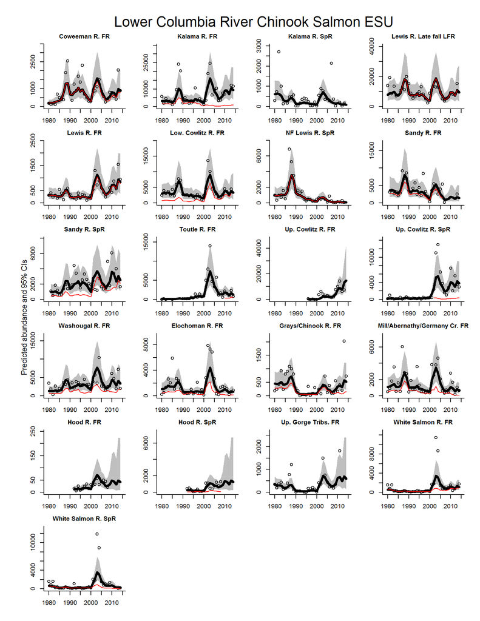

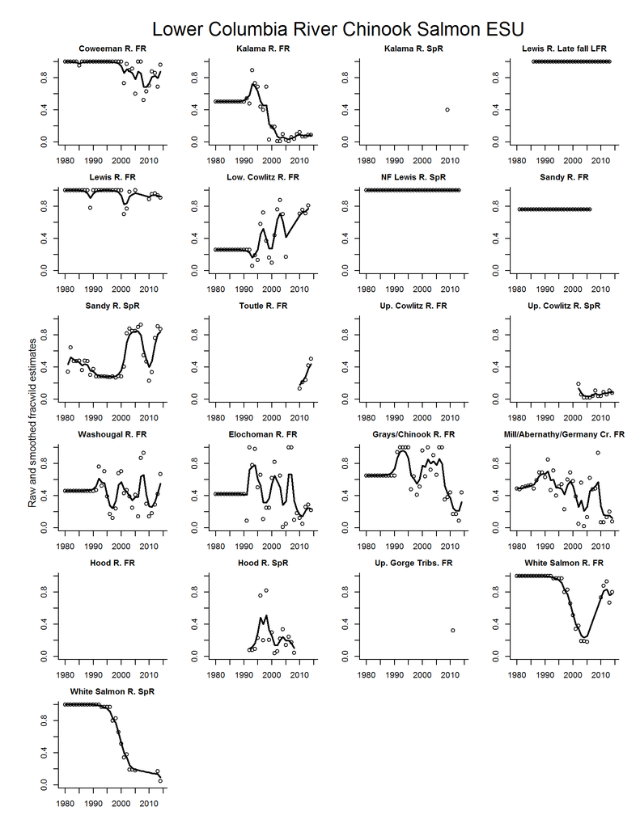

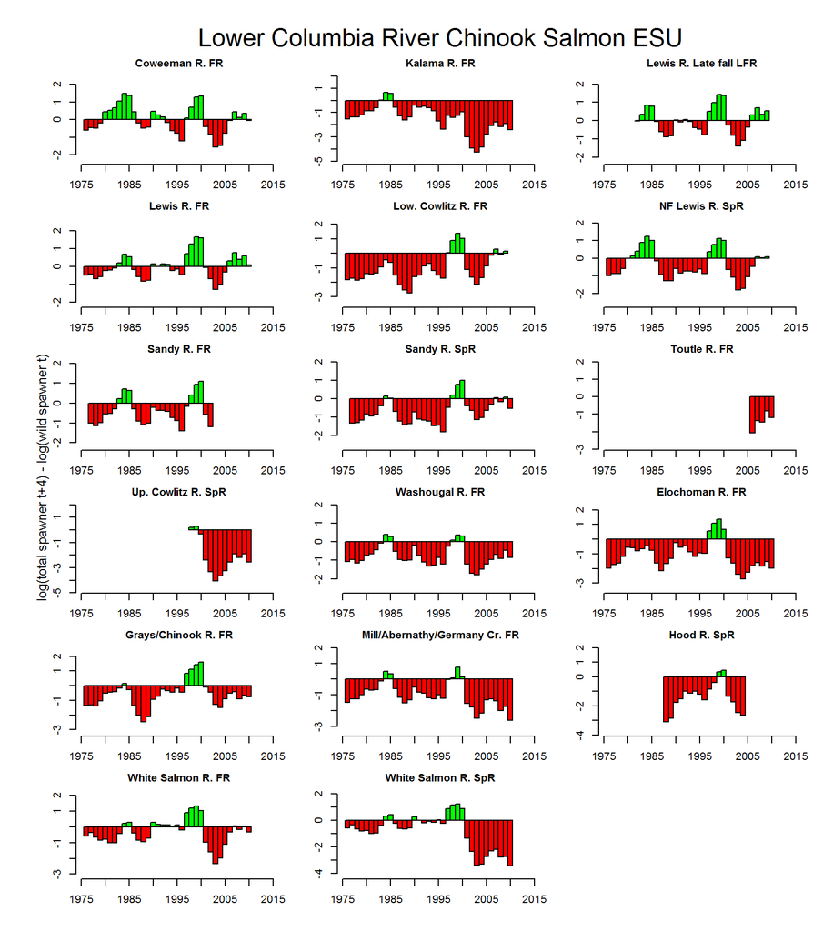

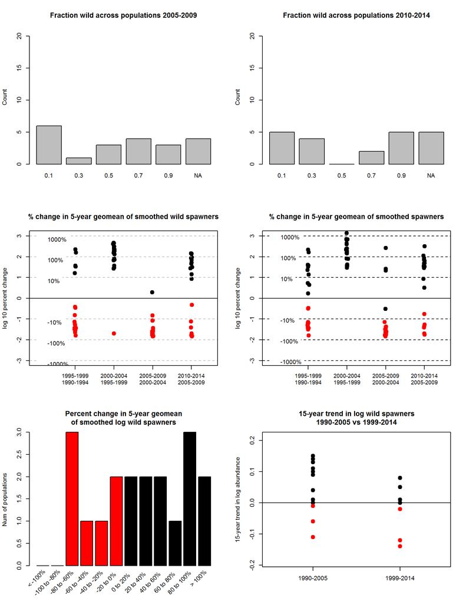

## 5-year geometric mean of smoothed wild spawners

5-year geometric mean of smoothed wild spawner estimate (smoothed total spawners times smoothed fracwild). In parentheses, the 5-year geometric mean of smoothed total spawners (black thick line in graphs) is shown. A row with only values in parentheses indicates that no fraction wild estimates were available for that population. Geometric mean was computed as the product of counts raised to the power 1/5. Percent change between the most recent two 5-year periods is shown on the far right.

| Population | MPG | 1990-1994 | 1995-1999 | 2000-2004 | 2005-2009 | 2010-2014 | % Change |
| --- | --- | --- | --- | --- | --- | --- | --- |
| Coweeman R. FR | Cascade | 792 (792) | 660 (665) | 838 (942) | 422 (547) | 641 (794) | 52 (45) |
| Kalama R. FR | Cascade | 2115 (3480) | 1455 (3369) | 741 (8276) | 313 (6034) | 769 (8981) | 146 (49) |
| Kalama R. SpR | Cascade | 59 (151) | 51 (130) | 147 (372) | 92 (232) | 47 (118) | -49 (-49) |
| Lewis R. Late fall LFR | Cascade | 7923 (7923) | 6409 (6409) | 11561 (11561) | 6336 (6336) | 9277 (9277) | 46 (46) |
| Lewis R. FR | Cascade | 233 (236) | 227 (229) | 572 (642) | 419 (443) | 707 (760) | 69 (72) |
| Low. Cowlitz R. FR | Cascade | 542 (2515) | 741 (2019) | 2613 (5125) | 1401 (2693) | 2569 (3470) | 83 (29) |
| NF Lewis R. SpR | Cascade | 949 (949) | 367 (367) | 502 (502) | 155 (155) | 115 (115) | -26 (-26) |
| Sandy R. FR | Cascade | 2612 (3437) | 1906 (2508) | 2472 (3252) | 1071 (1410) | 1164 (1532) | 9 (9) |
| Sandy R. SpR | Cascade | 557 (1849) | 541 (1881) | 1552 (2546) | 1375 (1960) | 1810 (2951) | 32 (51) |
| Toutle R. FR | Cascade | 36 (212) | 116 (676) | 632 (3643) | 328 (1875) | 418 (1473) | 27 (-21) |
| Up. Cowlitz R. FR | Cascade | (17) | (45) | (659) | (2397) | (10069) | (320) |
| Up. Cowlitz R. SpR | Cascade | 26 (194) | 35 (258) | 200 (2063) | 120 (2595) | 285 (3801) | 138 (46) |
| Washougal R. FR | Cascade | 1412 (2581) | 928 (2695) | 2127 (4828) | 1313 (2741) | 1286 (3647) | -2 (33) |
| Elochoman R. FR | Coastal | 362 (610) | 263 (643) | 1082 (2204) | 365 (901) | 143 (732) | -61 (-19) |
| Grays/Chinook R. FR | Coastal | 76 (85) | 47 (72) | 185 (230) | 129 (198) | 112 (422) | -13 (113) |
| Mill/Abernathy/Germany Cr. FR | Coastal | 644 (1060) | 362 (727) | 622 (1901) | 374 (844) | 130 (795) | -65 (-6) |
| Hood R. FR | Gorge | (13) | (16) | (42) | (32) | (43) | (34) |
| Hood R. SpR | Gorge | 28 (249) | 72 (183) | 120 (633) | 112 (768) | 128 (1247) | 14 (62) |
| Up. Gorge Tribs. FR | Gorge | 15 (47) | 20 (65) | 102 (326) | 104 (327) | 195 (611) | 88 (87) |
| White Salmon R. FR | Gorge | 130 (132) | 151 (185) | 490 (1454) | 432 (1025) | 827 (1058) | 91 (3) |
| White Salmon R. SpR | Gorge | 182 (184) | 170 (209) | 500 (1531) | 160 (903) | 52 (394) | -68 (-56) |

## 5-year geometric mean of raw wild spawners

5-year geometric mean of raw wild spawner counts. This is the raw total spawner count times the fraction wild estimate, if available. In parentheses, 5-year geometric mean of raw total spawner counts is shown. A value only in parentheses means that a total spawner count was available but no or only one estimate of wild spawners available. The geometric mean was computed as the product of counts raised to the power 1 over the number of counts available (2 to 5). A minimum of 2 values were used to compute the geometric mean. Percent change between the most recent two 5-year periods is shown on the far right.

[output not shown]

## Wild fraction

5-year mean of fraction wild (sum of all estimates divided by the number of estimates). Blanks (or NaN) mean no estimate available in that 5-year range.

| Population | 1990-1994 | 1995-1999 | 2000-2004 | 2005-2009 | 2010-2014 |
| --- | --- | --- | --- | --- | --- |
| Coweeman R. FR | 1.00 | 1.00 | 0.90 | 0.75 | 0.82 |
| Kalama R. FR | 0.63 | 0.45 | 0.10 | 0.05 | 0.09 |
| Kalama R. SpR | NaN | NaN | NaN | 0.40 | NaN |
| Lewis R. Late fall LFR | 1.00 | 1.00 | 1.00 | 1.00 | 1.00 |
| Lewis R. FR | 1.00 | 1.00 | 0.86 | 1.00 | 0.93 |
| Low. Cowlitz R. FR | 0.21 | 0.39 | 0.58 | 0.17 | 0.75 |
| NF Lewis R. SpR | 1.00 | 1.00 | 1.00 | 1.00 | 1.00 |
| Sandy R. FR | 0.76 | 0.76 | 0.76 | 0.76 | NaN |
| Sandy R. SpR | 0.30 | 0.28 | 0.65 | 0.74 | 0.62 |
| Toutle R. FR | NaN | NaN | NaN | NaN | 0.30 |
| Up. Cowlitz R. FR | NaN | NaN | NaN | NaN | NaN |
| Up. Cowlitz R. SpR | NaN | NaN | 0.09 | 0.05 | 0.08 |
| Washougal R. FR | 0.58 | 0.32 | 0.45 | 0.53 | 0.34 |
| Elochoman R. FR | 0.65 | 0.35 | 0.52 | 0.47 | 0.19 |
| Grays/Chinook R. FR | 0.92 | 0.61 | 0.84 | 0.68 | 0.26 |
| Mill/Abernathy/Germany Cr. FR | 0.61 | 0.51 | 0.32 | 0.53 | 0.11 |
| Hood R. FR | NaN | NaN | NaN | NaN | NaN |
| Hood R. SpR | 0.08 | 0.44 | 0.19 | 0.15 | NaN |
| Up. Gorge Tribs. FR | NaN | NaN | NaN | NaN | 0.32 |
| White Salmon R. FR | 0.99 | 0.85 | 0.32 | 0.18 | 0.80 |
| White Salmon R. SpR | 0.99 | 0.85 | 0.32 | 0.18 | 0.11 |

## 15-year trends

15-year trends (slope) in log wild spawner abundance computed from a linear regression applied to the smoothed wild spawner log abundance estimate versus year. In parentheses are the upper and lower 95% CIs. Only populations with at least 4 wild spawner estimates from 1980 to 2014 are shown and with at least 2 data points in the first 5 years and last 5 years of the 15-year period.

| Population | MPG | 1990-2005 | 1999-2014 |
| --- | --- | --- | --- |
| Coweeman R. FR | Cascade | 0.01 (-0.04, 0.06) | 0 (-0.06, 0.06) |
| Kalama R. FR | Cascade | -0.11 (-0.15, -0.06) | 0.01 (-0.05, 0.07) |
| Lewis R. Late fall LFR | Cascade | 0.04 (-0.01, 0.08) | 0.01 (-0.05, 0.06) |
| Lewis R. FR | Cascade | 0.09 (0.04, 0.14) | 0.05 (-0.01, 0.11) |
| Low. Cowlitz R. FR | Cascade | 0.14 (0.06, 0.22) | 0.05 (-0.04, 0.14) |
| NF Lewis R. SpR | Cascade | -0.06 (-0.12, -0.01) | -0.12 (-0.18, -0.06) |
| Sandy R. FR | Cascade | 0 (-0.05, 0.05) |  |
| Sandy R. SpR | Cascade | 0.11 (0.05, 0.17) | 0.05 (-0.01, 0.12) |
| Toutle R. FR | Cascade |  |  |
| Up. Cowlitz R. SpR | Cascade |  | 0.08 (0, 0.15) |
| Washougal R. FR | Cascade | 0.04 (-0.01, 0.09) | -0.02 (-0.07, 0.03) |
| Elochoman R. FR | Coastal | 0.1 (0.02, 0.17) | -0.14 (-0.23, -0.05) |
| Grays/Chinook R. FR | Coastal | 0.09 (0.02, 0.16) | 0 (-0.07, 0.07) |
| Mill/Abernathy/Germany Cr. FR | Coastal | -0.01 (-0.05, 0.04) | -0.12 (-0.18, -0.06) |
| Hood R. SpR | Gorge | 0.15 (0.1, 0.19) |  |
| White Salmon R. FR | Gorge | 0.13 (0.08, 0.18) | 0.08 (0.03, 0.14) |
| White Salmon R. SpR | Gorge | 0.09 (0.04, 0.15) |  |